# A_ KNN

## Aim: Basic machine learning concepts based on K- nearest neighbours method using the scikit-learn library.

The idea is to build an extremely simple form of object recognition system. Presently in spite of the fact that the model we'll use is basic, it reflects a considerable lot of a similar key AI ideas that go into building true commercial systems. The dataset we will utilize is a little, straightforward, model dataset and our target is to prepare a classifier to recognize various kinds of natural product.

#### Import required modules and load data file

We are going to do is to load the fruit dataset file using read table command in pandas. Now, this will read the dataset from disk, and store it into a data frame variable that we'll call fruits here.

```python
%matplotlib notebook
import numpy as np
import matplotlib.pyplot as plt
import pandas as pd
from sklearn.model_selection import train_test_split

fruits = pd.read_table('fruit_data_with_colors.txt')
```

```python
fruits.head()
```

|  | fruit_label | fruit_name | fruit_subtype | mass | width | height | color_score |
| --- | --- | --- | --- | --- | --- | --- | --- |
| 0 | 1 | apple | granny_smith | 192 | 8.4 | 7.3 | 0.55 |
| 1 | 1 | apple | granny_smith | 180 | 8.0 | 6.8 | 0.59 |
| 2 | 1 | apple | granny_smith | 176 | 7.4 | 7.2 | 0.60 |
| 3 | 2 | mandarin | mandarin | 86 | 6.2 | 4.7 | 0.80 |
| 4 | 2 | mandarin | mandarin | 84 | 6.0 | 4.6 | 0.79 |

The file contains the mass, height, and width of a selection of oranges, lemons and apples. The heights were measured along the core of the fruit. The widths were the widest width perpendicular to the height. And also here we can see that each row of the dataset represents one piece of fruit as represented by several features that are in the table's columns. So, in order, the columns that we see are fruit label. So this is the training label that we used. It's a number that corresponds to the general type of fruit. So for example, one is an apple, two is a mandarin orange, three is a regular orange, and so forth.

And finally, there's a feature stored in a column called color score that's meant to be a single number that captures a rough idea of the color of the fruit. So in a real system, this would actually be something more sophisticated, like a histogram of the distribution of colors, or maybe the pixels from an actual image or video of the fruit. But for our purposes, we're going to just summarize the color along a spectrum scale that'll be a handy summary that we can use that will just be easy to visualize. So scores close to one mean the fruit is red. Scores around 0.7 indicate yellow, and so forth.

```python
fruits.shape
```

```
(59, 7)
```

So, looking at this data frame, we can see that it contains 59 rows corresponding to 59 different pieces of fruit that have been measured and entered into the table. So our goal here is to build a classifier from this data that can predict the correct type of fruit for any given observation of its features such as mass, height, width, and color score. So for example, can we tell based on the color score and the dimensions, the difference between an orange and a lemon and have the classifier predict the type of piece of fruit correctly just from its observed measurements?

Now, assuming for the moment that we already we had a classifier ready to go, how would we know if its predictions were likely to be accurate?

Well, we could choose a fruit sample, called a test sample, for which we already had a label. So we could feed the features of that piece of fruit into the classifier, and then compare the label that the classifier predicts with the actual true label of the fruit type. So, here's a very important point though, if we use one of our labeled fruit examples in the data that we use to train the classifier, we can't also use that same fruit sample later as a test sample to also evaluate the classifier.

Why is that? Well, a key ability that our classifier needs to have is that it needs to work well on any input sample, any new pieces of fruit that we might see in the future, not just on the ones that we have on our training set.

Because our classifier could simply memorize every sample in the training set, it'd be pretty trivial to just give back the correct label for any one of the same samples later, right? So, measuring the classifier's performance later using the same samples that we've used to train it in the first place doesn't tell us anything about how well the classifier is likely to work for a fruit that we haven't seen before. It will only tell us what we already know about what's in the training set.

### Examining the data

Since our only source of labeled data is the dataset we've been given, to estimate how well the classifier will do on future samples, what we'll do is split the original dataset into two parts. We'll have an array of labeled samples called the training set that will be used to train the classifier. And then we'll hold out the remaining labeled samples and put them into a second separate array called the test set that will be used to then evaluate the trained classifier.

To create training and test sets from a input dataset, Scikit-learn provides a handy function that will do this split for us, called, not surprisingly, train test split. And here's an example of how we're going to use it.

This function randomly shuffles the dataset and splits off a certain percentage of the input samples for use as a training set, and then puts the remaining samples into a different variable for use as a test set. So in this example, we're using a 75-25% split of training versus test data. And that's a pretty standard relative split that's used. It's a good rule of thumb to use in deciding what proportion of training versus test might be helpful.

As a reminder, when we're using Scikit-learn, we'll denote the data that we have using different flavors of the variable X, which is typically a two dimensional array or data frame.

And the notation we'll use for labels will be typically based on y, which is usually a one dimensional array, or a scalar.

Now, note the use of the random state parameter in the train_test_split function. So this random state parameter provides a seed value to the function's internal random number generator.

If we choose different values for that seed value, that will result in different randomized splits for training and test.

The training test split function will put the training set here into X_train, the test set into X_test, the training labels into y_train, and the test labels into y_test. So this is a 75-25 partitioning of the original data into these two parts.

```python
# plotting a scatter matrix
from matplotlib import cm
from pandas.plotting import scatter_matrix

X = fruits[['height', 'width', 'mass', 'color_score']]
y = fruits['fruit_label']
X_train, X_test, y_train, y_test = train_test_split(X, y, random_state=0)
```

We'll put the rows of the data without the label, the training instances into this X variable, and the list of corresponding labels for those rows into a variable called y.

When using the training set and the test set, we'll then use X_train that holds the training instances to train the classifier, and X_test to evaluate the classifier after it's been trained.

Now that we have a training and a test set, we're ready for the next step.

First, it's helpful to simply get a sense for what's actually in the data set. because it may be that in inspecting the features of each object, one might get a better idea of what type of cleaning or preprocessing still needs to be done to the data. And of the range of values or the distribution of values that is typical for each attribute or each feature.

[figure not shown]

```python
cmap = cm.get_cmap('gnuplot')
scatter = scatter_matrix(X_train, c= y_train, marker = 'o', s=40, hist_kwds={'bins':15}, figsize=(9,9), cmap=cmap)
```

The first visualization tool we've used is called a feature pair plot and that's shown here.

So this plot shows all possible pairs of features and produces a scatter plot for each pair, showing how the features are correlated to each other or not.

Each point in the scatter plot represents a piece of fruit, colored according to the class it belongs to. And positioned using the parafeatures assigned to that scatter plot.

Along the diagonal is a histogram showing the distribution of feature values for that feature. So in this pair plot, the dimensions shown here in order are, height, width, mass and color score of the fruit examples in our training set.

So the upper left corner of the histogram here shows the distribution of the height feature for all samples in the training set. And the scatter plot to its immediate right plots the width of each sample on the x-axis and the height of the sample on the y-axis. Just by looking at this pair plot, we can already see that some pairs of features, like the height and color score in the top right corner here, are good for separating out different classes of fruit. And this suggests that a classifier that was trained using those features could likely learn to classify the various fruit types reasonably well. Here's the code that we'll use to create this plot, and let's run this now on our training set.

Note that a pair plot like this does not show interactions between all features that might exist, just between pairs of them.

So the plot itself may not show all the interesting relationships that do exist between the features.

But it does give you a rough idea of some of the interactions that might exist.

We can also look at features that use a subset of three features by creating a three dimensional plot.

So in this example, we plot different fruits using three coordinates. So here we'll the show the width, the height, and the color score. Here again, each point represents a single piece of fruit and its color according to its fruit label value.

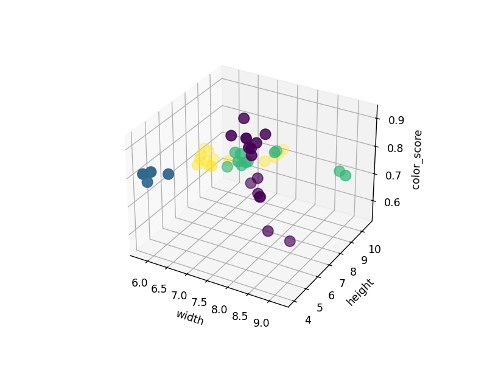

```python
# plotting a 3D scatter plot
from mpl_toolkits.mplot3d import Axes3D

fig = plt.figure()
ax = fig.add_subplot(111, projection = '3d')
ax.scatter(X_train['width'], X_train['height'], X_train['color_score'], c = y_train, marker = 'o', s=100)
ax.set_xlabel('width')
ax.set_ylabel('height')
ax.set_zlabel('color_score')
plt.show()
```

We've gotten a sense for what's in our data set, as a simple example to get started, we're going to use this data set to train a classifier that will automatically identify any future pieces of fruit that might come our way based on the features available to the classifier such as the object's color, size and mass. To do this, we'll use a popular and easy to understand type of machine learning algorithm known as k-nearest neighbors or k-NN.

The K-Nearest Neighbors algorithm can be used for classification and regression. k-NN classifiers are an example of what's called instance based or memory based supervised learning. What this means is that instance based learning methods work by memorizing the labeled examples that they see in the training set. And then they use those memorized examples to classify new objects later.